# Hidden vs Visible Resources in the Survival Game (Study 4)

Scott Claessens

2019-09-16

# 0. Setup

You’ll need to download [Stan](http://mc-stan.org/) to your machine for these analyses. Note: this document will save **brms** model fits into your working directory.

First, let’s install all the packages we’ll need.

```r
library(brms)
library(cowplot)
library(ggplot2)
library(tidyverse)
```

Now, read in the data from Study 4.

```r
(
  d <-
    read.csv('data/exp4data.csv', header = TRUE) %>%
    as_tibble()
)
```

| ID | Group | IDinGroup | Condition | Payment | TimeStarted | Age | Sex | Language | rounds_survived | total_cattle_lost | overall_total_amount_requested | overall_total_amount_received | overall_total_amount_given | overall_received_given_totaldiff | overall_mean_amount_requested | overall_mean_amount_received | overall_mean_amount_given | overall_num_shocks | overall_num_requests_made | overall_num_requests_when_under_threshold | overall_num_requests_responded_to | overall_repetitive_giving | overall_repetitive_asking | payment_for_lobby | payment_from_game | attention | feel_bad_ask | fairness | risk_pooling_true | … |
| --- | --- | --- | --- | --- | --- | --- | --- | --- | --- | --- | --- | --- | --- | --- | --- | --- | --- | --- | --- | --- | --- | --- | --- | --- | --- | --- | --- | --- | --- | --- |
| 1 | 1 | 1 | 1 | 3.95 | 2019-08-27 20:35:26.994342+00:00 | 29 | 3 | 1 | 7 | 32 | 22 | 1 | 7 | -6 | 3.1428571 | 0.14285714 | 1.0000000 | 3 | 4 | 4 | 2 | 0 | 0 | 0 | 46 | 6 | 3 | 4 | 4 | … |
| 2 | 1 | 2 | 1 | 5.39 | 2019-08-27 20:33:08.550976+00:00 | 28 | 1 | 1 | 25 | 43 | 44 | 7 | 1 | 6 | 1.7600000 | 0.28000000 | 0.0400000 | 3 | 6 | 5 | 1 | 0 | 3 | 2 | 188 | 6 | 4 | 3 | 2 | … |
| 3 | 2 | 1 | 1 | 5.59 | 2019-08-27 20:41:43.054960+00:00 | 21 | 1 | 1 | 25 | 49 | 16 | 21 | 13 | 8 | 0.6400000 | 0.84000000 | 0.5200000 | 4 | 6 | 0 | 3 | 1 | 4 | 1 | 208 | 3 | 3 | 4 | 5 | … |
| 4 | 2 | 2 | 1 | 5.96 | 2019-08-27 20:38:10.881016+00:00 | 21 | 2 | 1 | 25 | 23 | 9 | 13 | 21 | -8 | 0.3600000 | 0.52000000 | 0.8400000 | 2 | 3 | 0 | 5 | 3 | 1 | 26 | 221 | 6 | 4 | 5 | 5 | … |
| 5 | 3 | 1 | 1 | 5.35 | 2019-08-27 20:49:58.650505+00:00 | 18 | 1 | 1 | 25 | 41 | 52 | 14 | 19 | -5 | 2.0800000 | 0.56000000 | 0.7600000 | 3 | 18 | 1 | 10 | 5 | 9 | 0 | 186 | 1 | 2 | 3 | 3 | … |
| 6 | 3 | 2 | 1 | 5.81 | 2019-08-27 20:47:56.858992+00:00 | 39 | 2 | 1 | 25 | 21 | 27 | 19 | 14 | 5 | 1.0800000 | 0.76000000 | 0.5600000 | 3 | 12 | 0 | 8 | 3 | 5 | 15 | 218 | 6 | 3 | 3 | 4 | … |
| 7 | 4 | 1 | 1 | 5.38 | 2019-08-27 20:49:34.266959+00:00 | 33 | 1 | 1 | 25 | 65 | 5 | 3 | 3 | 0 | 0.2000000 | 0.12000000 | 0.1200000 | 5 | 1 | 0 | 1 | 0 | 0 | 10 | 178 | 6 | 4 | 5 | 5 | … |
| 8 | 4 | 2 | 1 | 5.82 | 2019-08-27 20:53:06.391080+00:00 | 29 | 2 | 1 | 25 | 65 | 3 | 3 | 3 | 0 | 0.1200000 | 0.12000000 | 0.1200000 | 5 | 1 | 0 | 1 | 0 | 0 | 0 | 233 | 6 | 4 | 5 | 5 | … |
| 9 | 5 | 1 | 1 | 5.20 | 2019-08-27 20:48:33.230516+00:00 | 46 | 1 | 2 | 25 | 66 | 22 | 18 | 2 | 16 | 0.8800000 | 0.72000000 | 0.0800000 | 6 | 3 | 3 | 1 | 0 | 2 | 0 | 170 | 6 | 2 | 5 | 5 | … |
| 10 | 5 | 2 | 1 | 3.85 | 2019-08-27 20:51:44.746951+00:00 | 42 | 2 | 1 | 5 | 14 | 2 | 2 | 18 | -16 | 0.4000000 | 0.40000000 | 3.6000000 | 2 | 1 | 1 | 3 | 2 | 0 | 4 | 31 | 6 | 4 | 4 | 4 | … |

[output cut: 74 more lines]

Each row is a different participant in the study (there were 84). Columns 1-36 are variables that summarise the whole session, while the rest of the columns specify the events that occurred in each of the 25 rounds.

# 1. Binomial - Number of shocks

We’ll trim the dataset, to make it more manageable.

```r
(
  d.trim <-
    d %>%
    select(Condition, rounds_survived, overall_num_shocks)
)
```

| Condition | rounds_survived | overall_num_shocks |
| --- | --- | --- |
| 1 | 7 | 3 |
| 1 | 25 | 3 |
| 1 | 25 | 4 |
| 1 | 25 | 2 |
| 1 | 25 | 3 |
| 1 | 25 | 3 |
| 1 | 25 | 5 |
| 1 | 25 | 5 |
| 1 | 25 | 6 |
| 1 | 5 | 2 |

[output cut: 74 more lines]

In this dataset, Condition == 1 implies that the participant played the Survival Game in the ‘Hidden’ condition. Unlike in Study 1, ‘Hidden’ here means that Player 2’s resources were hidden, while Player 1’s resources were visible as normal. Condition == 0 refers to the standard ‘Visible’ control condition.

We first test whether the probability of a shock occurring differs between the two conditions. All analyses in this document will use the `brm()` function. Learn more about the **brms** package [here](https://github.com/paul-buerkner/brms). Also, see [here](https://bookdown.org/content/1850/horoscopes-insights.html#use-the-0-intercept-syntax) for an explanation of why I use the `0 + intercept` syntax throughout this document.

```r
b4.1 <-
  brm(data = d.trim, family = binomial,
      overall_num_shocks | trials(rounds_survived) ~ 0 + intercept + Condition,
      prior = c(prior(normal(0, 1), class = b)),
      sample_prior = TRUE,
      iter = 2000, warmup = 1000, chains = 4, cores = 4,
      seed = 2113)

save(b4.1, file = "models/exp4_brmsfit1.rda")
```

Priors.

```r
prior_summary(b4.1)
```

| prior | class | coef | group | resp | dpar | nlpar | bound |
| --- | --- | --- | --- | --- | --- | --- | --- |
| normal(0, 1) | b |  |  |  |  |  |  |
|  | b | Condition |  |  |  |  |  |
|  | b | intercept |  |  |  |  |  |

Let’s look at the results.

```r
print(b4.1)
```

```
##  Family: binomial
##   Links: mu = logit
## Formula: overall_num_shocks | trials(rounds_survived) ~ 0 + intercept + Condition
##    Data: d.trim (Number of observations: 84)
## Samples: 4 chains, each with iter = 2000; warmup = 1000; thin = 1;
##          total post-warmup samples = 4000
##
## Population-Level Effects:
##           Estimate Est.Error l-95% CI u-95% CI Eff.Sample Rhat
## intercept    -1.43      0.09    -1.61    -1.25       1405 1.00
## Condition    -0.00      0.13    -0.26     0.25       1378 1.00
##
## Samples were drawn using sampling(NUTS). For each parameter, Eff.Sample
## is a crude measure of effective sample size, and Rhat is the potential
## scale reduction factor on split chains (at convergence, Rhat = 1).
```

The probability of a shock occuring does not differ across conditions.

# 2. Gaussian - Total amount of cattle lost due to shocks

Trim the dataset again.

```r
(
  d.trim <-
    d %>%
    select(Condition, total_cattle_lost)
)
```

| Condition | total_cattle_lost |
| --- | --- |
| 1 | 32 |
| 1 | 43 |
| 1 | 49 |
| 1 | 23 |
| 1 | 41 |
| 1 | 21 |
| 1 | 65 |
| 1 | 65 |
| 1 | 66 |
| 1 | 14 |

[output cut: 74 more lines]

We now fit a model to determine if the total amount of cattle lost due to shocks varies between conditions.

```r
b4.2 <-
  brm(data = d.trim, family = gaussian,
      total_cattle_lost ~ 0 + intercept + Condition,
      prior = c(prior(normal(0, 100), class = b, coef = 'intercept'),
                prior(normal(0, 5), class = b, coef = 'Condition')),
      sample_prior = TRUE,
      iter = 2000, warmup = 1000, chains = 4, cores = 4,
      seed = 2113)

save(b4.2, file = "models/exp4_brmsfit2.rda")
```

The priors we used.

```r
prior_summary(b4.2)
```

| prior | class | coef | group | resp | dpar | nlpar | bound |
| --- | --- | --- | --- | --- | --- | --- | --- |
|  | b |  |  |  |  |  |  |
| normal(0, 5) | b | Condition |  |  |  |  |  |
| normal(0, 100) | b | intercept |  |  |  |  |  |
| student_t(3, 0, 23) | sigma |  |  |  |  |  |  |

The results.

```r
print(b4.2)
```

```
##  Family: gaussian
##   Links: mu = identity; sigma = identity
## Formula: total_cattle_lost ~ 0 + intercept + Condition
##    Data: d.trim (Number of observations: 84)
## Samples: 4 chains, each with iter = 2000; warmup = 1000; thin = 1;
##          total post-warmup samples = 4000
##
## Population-Level Effects:
##           Estimate Est.Error l-95% CI u-95% CI Eff.Sample Rhat
## intercept    44.43      2.97    38.71    50.25       2645 1.00
## Condition    -3.05      3.29    -9.25     3.44       2361 1.00
##
## Family Specific Parameters:
##       Estimate Est.Error l-95% CI u-95% CI Eff.Sample Rhat
## sigma    22.01      1.76    18.85    25.67       2673 1.00
##
## Samples were drawn using sampling(NUTS). For each parameter, Eff.Sample
## is a crude measure of effective sample size, and Rhat is the potential
## scale reduction factor on split chains (at convergence, Rhat = 1).
```

The total amount of cattle lost does not vary between conditions.

# 3. Binomial - Probability of requesting

Get a long-format data frame with binary request decisions over all rounds. If request == NA, player has died and been removed from the game, so we drop those rows. We also retain only Player 2s.

```r
(
  d.trim <-
    d %>%
    select(ID, Group, IDinGroup, Condition, ends_with('.player.request')) %>%
    gather(round_number, request, ends_with('.player.request')) %>%
    mutate(round_number = rep(1:25, each = 84)) %>%
    drop_na() %>%
    filter(IDinGroup == 2)
)
```

| ID | Group | IDinGroup | Condition | round_number | request |
| --- | --- | --- | --- | --- | --- |
| 2 | 1 | 2 | 1 | 1 | 1 |
| 4 | 2 | 2 | 1 | 1 | 0 |
| 6 | 3 | 2 | 1 | 1 | 1 |
| 8 | 4 | 2 | 1 | 1 | 0 |
| 10 | 5 | 2 | 1 | 1 | 1 |
| 12 | 6 | 2 | 1 | 1 | 0 |
| 14 | 7 | 2 | 1 | 1 | 1 |
| 16 | 8 | 2 | 1 | 1 | 1 |
| 18 | 9 | 2 | 1 | 1 | 0 |
| 20 | 10 | 2 | 1 | 1 | 0 |

[output cut: 667 more lines]

This leaves us with 677 request decisions.

We now fit a varying intercept and slope model, grouped by participant. We only allow the slope for round number to vary, as participants completed multiple rounds (within-subjects) but only one condition, Hidden or Visible (between-subjects).

```r
b4.3 <-
  brm(data = d.trim, family = bernoulli,
      request ~ 0 + intercept + round_number + Condition
      + (0 + intercept + round_number | ID),
      prior = c(prior(normal(0, 1), class = b)),
      sample_prior = TRUE,
      iter = 2000, warmup = 1000, chains = 4, cores = 4,
      control = list(adapt_delta = 0.95),
      seed = 2113)

save(b4.3, file = "models/exp4_brmsfit3.rda")
```

Here are the priors for the model we just fitted.

```r
prior_summary(b4.3)
```

| prior | class | coef | group | resp | dpar | nlpar | bound |
| --- | --- | --- | --- | --- | --- | --- | --- |
| normal(0, 1) | b |  |  |  |  |  |  |
|  | b | Condition |  |  |  |  |  |
|  | b | intercept |  |  |  |  |  |
|  | b | round_number |  |  |  |  |  |
| lkj_corr_cholesky(1) | L |  |  |  |  |  |  |
|  | L |  | ID |  |  |  |  |
| student_t(3, 0, 10) | sd |  |  |  |  |  |  |
|  | sd |  | ID |  |  |  |  |
|  | sd | intercept | ID |  |  |  |  |
|  | sd | round_number | ID |  |  |  |  |

Now let’s see the results.

```r
print(b4.3)
```

```
##  Family: bernoulli
##   Links: mu = logit
## Formula: request ~ 0 + intercept + round_number + Condition + (0 + intercept + round_number | ID)
##    Data: d.trim (Number of observations: 677)
## Samples: 4 chains, each with iter = 2000; warmup = 1000; thin = 1;
##          total post-warmup samples = 4000
##
## Group-Level Effects:
## ~ID (Number of levels: 42)
##                             Estimate Est.Error l-95% CI u-95% CI Eff.Sample Rhat
## sd(intercept)                   1.50      0.37     0.83     2.31       2004 1.00
## sd(round_number)                0.11      0.05     0.02     0.22        645 1.01
## cor(intercept,round_number)     0.00      0.39    -0.66     0.81       1328 1.00
##
## Population-Level Effects:
##              Estimate Est.Error l-95% CI u-95% CI Eff.Sample Rhat
## intercept       -0.64      0.38    -1.39     0.09       2219 1.00
## round_number    -0.08      0.03    -0.16    -0.03       1800 1.00
## Condition        0.12      0.48    -0.84     1.06       2237 1.00
##
## Samples were drawn using sampling(NUTS). For each parameter, Eff.Sample
## is a crude measure of effective sample size, and Rhat is the potential
## scale reduction factor on split chains (at convergence, Rhat = 1).
```

Plotting the parameters.

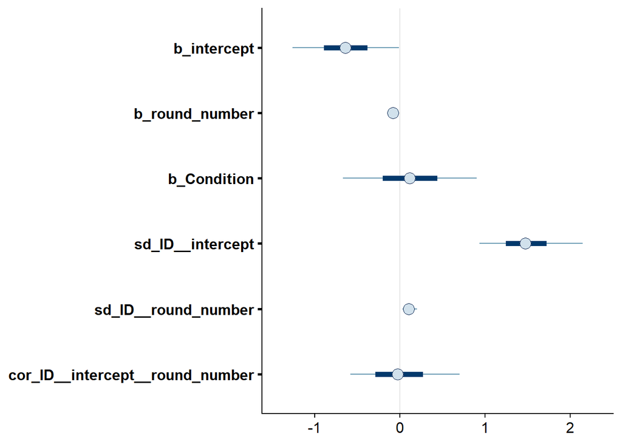

```r
stanplot(b4.3)
```

Trace plots to make sure Stan sampled efficiently.

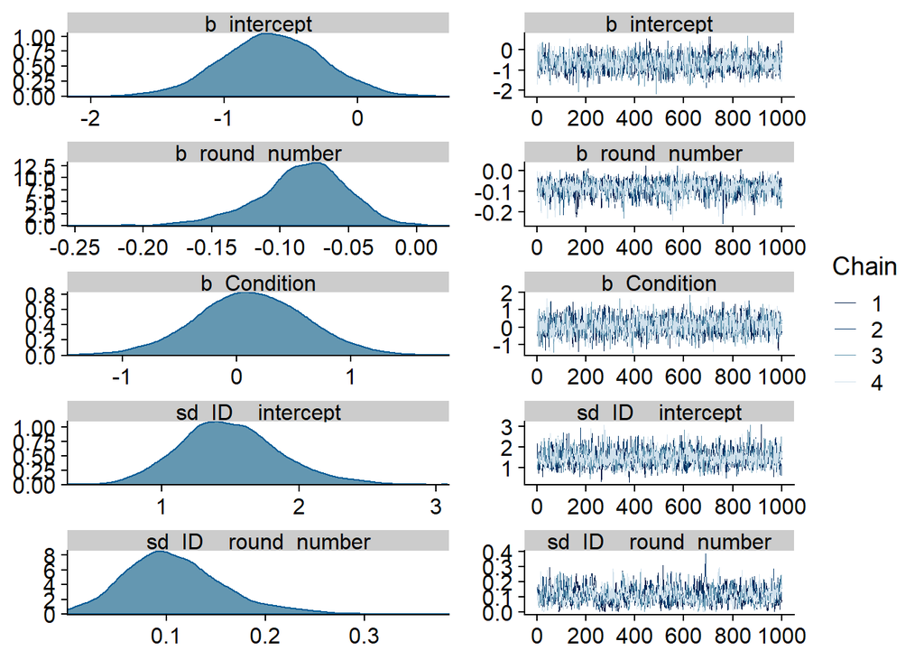

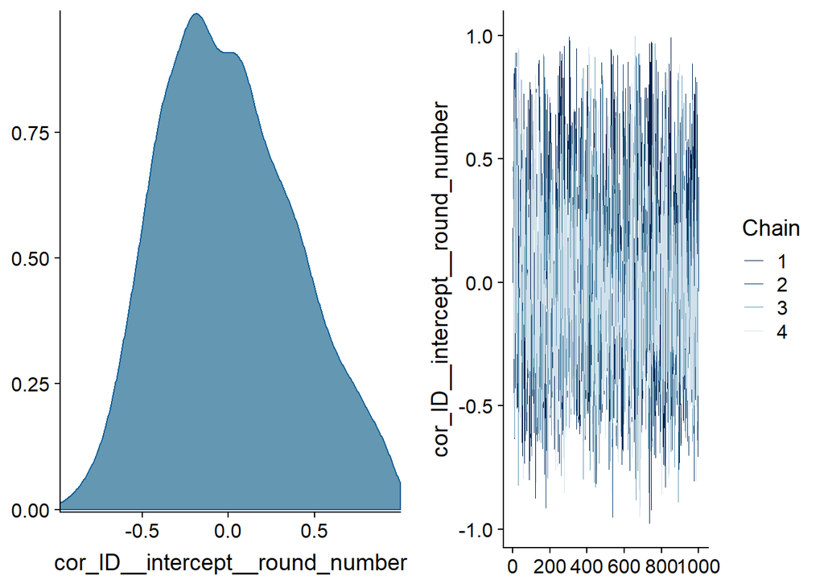

```r
plot(b4.3, ask = F)
```

Looks like Stan sampled efficiently.

There seems to be no effect of condition on the probability of requesting for Player 2s.

Let’s sample from the posterior and convert to the probability scale.

```r
post <- posterior_samples(b4.3)

visible_prob <- inv_logit_scaled(post$b_intercept)

visible_prob %>%
  median() %>%
  round(2)
```

```
## [1] 0.34
```

```r
hidden_prob  <- inv_logit_scaled(post$b_intercept + post$b_Condition)

hidden_prob %>%
  median() %>%
  round(2)
```

```
## [1] 0.37
```

```r
difference <- hidden_prob - visible_prob
quantile(difference, c(0.025, 0.5, 0.975)) %>% round(2)
```

```
##  2.5%   50% 97.5%
## -0.19  0.03  0.24
```

Bayes factor for the difference between probabilities being equal to zero.

```r
(1 / hypothesis(b4.3, "inv_logit_scaled(intercept + Condition) - inv_logit_scaled(intercept) = 0", seed = 2113)$hypothesis$Evid.Ratio) %>% round(2)
```

```
## [1] 0.56
```

This Bayes factor implies that we cannot be certain whether the difference between these probabilities is different or equal to zero, though it is verging on equal.

How much variance in the outcome does this model explain? We use the `bayes_R2()` function to get a Bayesian estimate of R-squared.

```r
bayes_R2(b4.3) %>% round(2)
```

```
##    Estimate Est.Error Q2.5 Q97.5
## R2     0.33      0.03 0.27  0.38
```

This model explains around 33% of the variance in requesting behaviour.

# 4. Binomial - Probability of requesting when above the minimum threshold

As before, get a long-format data frame with binary request decisions over all rounds. If request == NA, player has died and been removed from the game, so we drop those rows. However, we also filter out rows in which the player was below the minimum survival threshold (64 cattle). As before, we also retain only Player 2s.

```r
(
  d.trim <-
    d %>%
    select(ID, IDinGroup, Condition, ends_with('.player.herd_size_after_shock'),
           ends_with('.player.request')) %>%
    gather(key, value, -ID, -IDinGroup, -Condition) %>%
    extract(key, c("round_number", "variable"),
            "SurvivalGame.(.|..).player.(herd_size_after_shock|request)") %>%
    spread(variable, value) %>%
    mutate(round_number = as.integer(round_number)) %>%
    arrange(round_number, ID) %>%
    drop_na() %>%                            # drop NAs, as player is no longer alive
    filter(herd_size_after_shock >= 64) %>%  # only rounds above the minimum threshold
    filter(IDinGroup == 2)
)
```

| ID | IDinGroup | Condition | round_number | herd_size_after_shock | request |
| --- | --- | --- | --- | --- | --- |
| 4 | 2 | 1 | 1 | 72 | 0 |
| 6 | 2 | 1 | 1 | 71 | 1 |
| 8 | 2 | 1 | 1 | 72 | 0 |
| 14 | 2 | 1 | 1 | 73 | 1 |
| 16 | 2 | 1 | 1 | 68 | 1 |
| 18 | 2 | 1 | 1 | 74 | 0 |
| 22 | 2 | 1 | 1 | 64 | 1 |
| 24 | 2 | 1 | 1 | 68 | 1 |
| 28 | 2 | 1 | 1 | 73 | 0 |
| 30 | 2 | 1 | 1 | 72 | 0 |

[output cut: 590 more lines]

This leaves us with 600 request decisions.

Fit the varying intercept and slope model, grouped by participant.

```r
b4.4 <-
  brm(data = d.trim, family = bernoulli,
      request ~ 0 + intercept + round_number + Condition
      + (0 + intercept + round_number | ID),
      prior = c(prior(normal(0, 1), class = b)),
      sample_prior = TRUE,
      iter = 2000, warmup = 1000, chains = 4, cores = 4,
      control = list(adapt_delta = 0.95),
      seed = 2113)

save(b4.4, file = "models/exp4_brmsfit4.rda")
```

Here are the priors for this model.

```r
prior_summary(b4.4)
```

| prior | class | coef | group | resp | dpar | nlpar | bound |
| --- | --- | --- | --- | --- | --- | --- | --- |
| normal(0, 1) | b |  |  |  |  |  |  |
|  | b | Condition |  |  |  |  |  |
|  | b | intercept |  |  |  |  |  |
|  | b | round_number |  |  |  |  |  |
| lkj_corr_cholesky(1) | L |  |  |  |  |  |  |
|  | L |  | ID |  |  |  |  |
| student_t(3, 0, 10) | sd |  |  |  |  |  |  |
|  | sd |  | ID |  |  |  |  |
|  | sd | intercept | ID |  |  |  |  |
|  | sd | round_number | ID |  |  |  |  |

Let’s see the results.

```r
print(b4.4)
```

```
##  Family: bernoulli
##   Links: mu = logit
## Formula: request ~ 0 + intercept + round_number + Condition + (0 + intercept + round_number | ID)
##    Data: d.trim (Number of observations: 600)
## Samples: 4 chains, each with iter = 2000; warmup = 1000; thin = 1;
##          total post-warmup samples = 4000
##
## Group-Level Effects:
## ~ID (Number of levels: 39)
##                             Estimate Est.Error l-95% CI u-95% CI Eff.Sample Rhat
## sd(intercept)                   1.61      0.44     0.85     2.60       1219 1.00
## sd(round_number)                0.08      0.05     0.01     0.21        415 1.01
## cor(intercept,round_number)     0.01      0.46    -0.78     0.91       1404 1.00
##
## Population-Level Effects:
##              Estimate Est.Error l-95% CI u-95% CI Eff.Sample Rhat
## intercept       -0.93      0.42    -1.74    -0.13       1784 1.00
## round_number    -0.10      0.04    -0.20    -0.04        780 1.00
## Condition       -0.29      0.53    -1.32     0.75       2114 1.00
##
## Samples were drawn using sampling(NUTS). For each parameter, Eff.Sample
## is a crude measure of effective sample size, and Rhat is the potential
## scale reduction factor on split chains (at convergence, Rhat = 1).
```

Plotting the parameters.

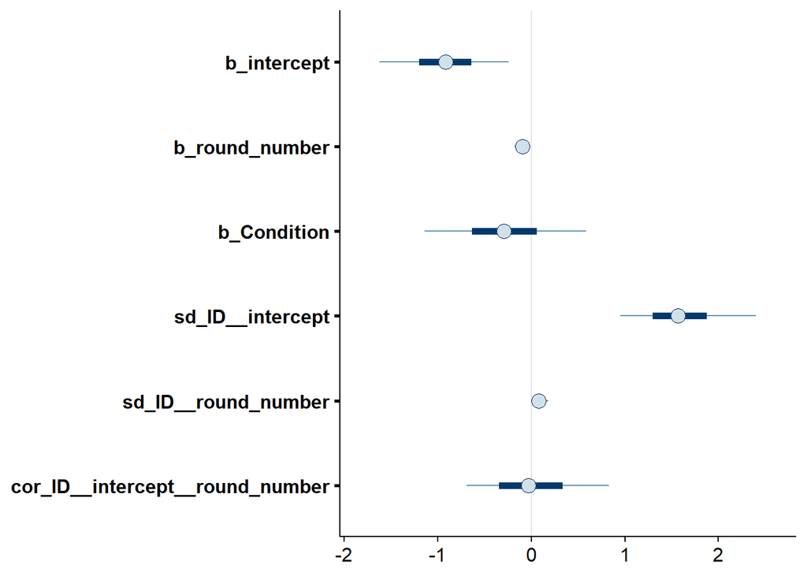

```r
stanplot(b4.4)
```

Trace plots to make sure Stan sampled efficiently.

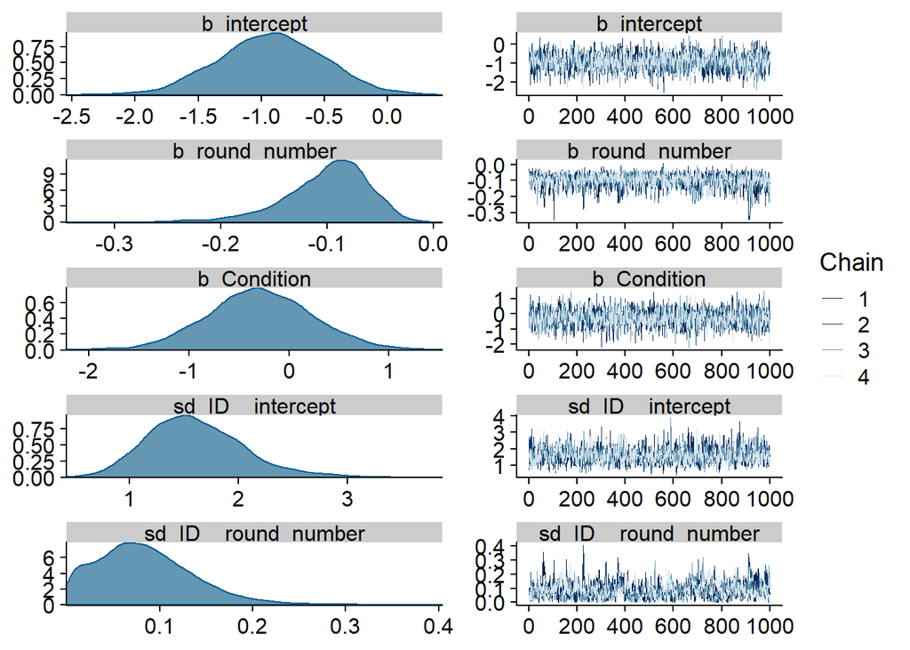

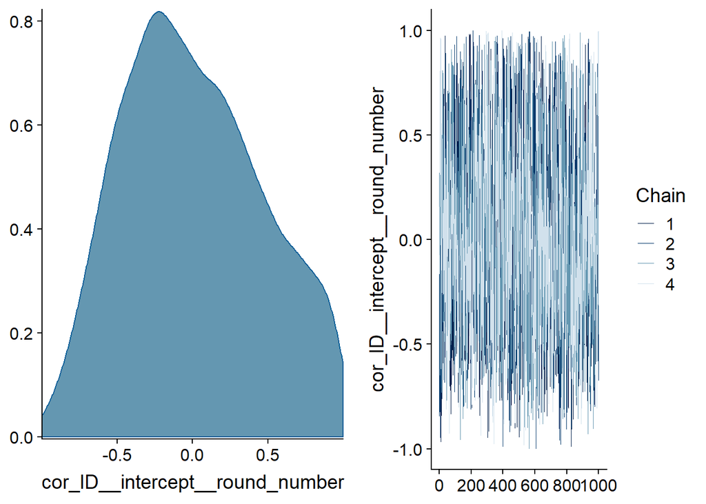

```r
plot(b4.4, ask = F)
```

These HMC chains look healthy.

As with our previous model, it doesn’t look like condition is having an effect. Get the probabilities of requesting while above the threshold (greediness) in both conditions.

```r
post <- posterior_samples(b4.4)

visible_prob <- inv_logit_scaled(post$b_intercept)

visible_prob %>%
  median() %>%
  round(2)
```

```
## [1] 0.29
```

```r
hidden_prob  <- inv_logit_scaled(post$b_intercept + post$b_Condition)

hidden_prob %>%
  median() %>%
  round(2)
```

```
## [1] 0.23
```

```r
difference <- hidden_prob - visible_prob
quantile(difference, c(0.025, 0.5, 0.975)) %>% round(2)
```

```
##  2.5%   50% 97.5%
## -0.25 -0.05  0.15
```

Greediness is comparable across conditions. Get a Bayes factor for this difference.

```r
(1 / hypothesis(b4.4, "inv_logit_scaled(intercept + Condition) - inv_logit_scaled(intercept) = 0", seed = 2113)$hypothesis$Evid.Ratio) %>% round(2)
```

```
## [1] 0.59
```

This Bayes factor implies that we cannot be certain whether the probabilities are different or equal.

We use the `bayes_R2()` function to get a Bayesian estimate of R-squared.

```r
bayes_R2(b4.4) %>% round(2)
```

```
##    Estimate Est.Error Q2.5 Q97.5
## R2     0.31      0.03 0.24  0.36
```

This model explains around 31% of the variance in the outcome.

# 5. Binomial - Probability of not responding to a request

Get long-format data frame with ‘received’ variable (i.e. how much a player received on any given round). We swap this around so it reflects how much the player *gave* to their partner (i.e. how much their partner received). We drop rows with NAs, since partners did not request help in that particular round. We then code whether the player gave nothing in response to the request (1) or gave at least one cattle (0). Finally, we retain only Player 2s.

```r
(
  d.trim <-
    d %>%
    select(ID, IDinGroup, Condition, ends_with('.player.received')) %>%
    # swap every other value to get what the player GAVE, rather than what they RECEIVED
    # swapping works because each player is next to their partner in the data frame
    mutate_at(vars(ends_with(".player.received")), function(x) x[1:nrow(d) + c(1,-1)]) %>%
    gather(round_number, responded, ends_with('.player.received')) %>%
    mutate(round_number = rep(1:25, each = 84)) %>%
    # drop NAs, as no requesting happened
    drop_na() %>%
    # 0 = responded, 1 = did not respond
    mutate(notResponded = ifelse(responded > 0, 0, 1) %>% as.integer()) %>%
    filter(IDinGroup == 2)
)
```

| ID | IDinGroup | Condition | round_number | responded | notResponded |
| --- | --- | --- | --- | --- | --- |
| 6 | 2 | 1 | 1 | 0 | 1 |
| 8 | 2 | 1 | 1 | 3 | 0 |
| 12 | 2 | 1 | 1 | 1 | 0 |
| 20 | 2 | 1 | 1 | 0 | 1 |
| 22 | 2 | 1 | 1 | 1 | 0 |
| 30 | 2 | 1 | 1 | 4 | 0 |
| 32 | 2 | 1 | 1 | 0 | 1 |
| 42 | 2 | 1 | 1 | 5 | 0 |
| 46 | 2 | 0 | 1 | 3 | 0 |
| 48 | 2 | 0 | 1 | 1 | 0 |

[output cut: 184 more lines]

This leaves us with 194 possible responses to requests.

We then fit the varying intercept and slope model, again grouped by participant.

```r
b4.5 <-
  brm(data = d.trim, family = bernoulli,
      notResponded ~ 0 + intercept + round_number + Condition
      + (0 + intercept + round_number | ID),
      prior = c(prior(normal(0, 1), class = b),
                prior(student_t(3, 0, 10), class = sd),
                prior(lkj(1), class = cor)),
      sample_prior = TRUE,
      iter = 2500, warmup = 1000, chains = 4, cores = 4,
      control = list(adapt_delta = 0.99),
      seed = 2113)

save(b4.5, file = "models/exp4_brmsfit5.rda")
```

Here are the priors for the model we just fitted.

```r
prior_summary(b4.5)
```

| prior | class | coef | group | resp | dpar | nlpar | bound |
| --- | --- | --- | --- | --- | --- | --- | --- |
| normal(0, 1) | b |  |  |  |  |  |  |
|  | b | Condition |  |  |  |  |  |
|  | b | intercept |  |  |  |  |  |
|  | b | round_number |  |  |  |  |  |
| lkj_corr_cholesky(1) | L |  |  |  |  |  |  |
|  | L |  | ID |  |  |  |  |
| student_t(3, 0, 10) | sd |  |  |  |  |  |  |
|  | sd |  | ID |  |  |  |  |
|  | sd | intercept | ID |  |  |  |  |
|  | sd | round_number | ID |  |  |  |  |

The results.

```r
print(b4.5)
```

```
##  Family: bernoulli
##   Links: mu = logit
## Formula: notResponded ~ 0 + intercept + round_number + Condition + (0 + intercept + round_number | ID)
##    Data: d.trim (Number of observations: 194)
## Samples: 4 chains, each with iter = 2500; warmup = 1000; thin = 1;
##          total post-warmup samples = 6000
##
## Group-Level Effects:
## ~ID (Number of levels: 39)
##                             Estimate Est.Error l-95% CI u-95% CI Eff.Sample Rhat
## sd(intercept)                   0.78      0.52     0.04     1.92       1334 1.00
## sd(round_number)                0.10      0.08     0.00     0.28        626 1.01
## cor(intercept,round_number)     0.01      0.55    -0.91     0.95        827 1.01
##
## Population-Level Effects:
##              Estimate Est.Error l-95% CI u-95% CI Eff.Sample Rhat
## intercept       -1.84      0.47    -2.78    -0.97       4238 1.00
## round_number     0.04      0.04    -0.05     0.13       3150 1.00
## Condition        1.01      0.49    -0.01     1.93       4110 1.00
##
## Samples were drawn using sampling(NUTS). For each parameter, Eff.Sample
## is a crude measure of effective sample size, and Rhat is the potential
## scale reduction factor on split chains (at convergence, Rhat = 1).
```

Plotting the parameters.

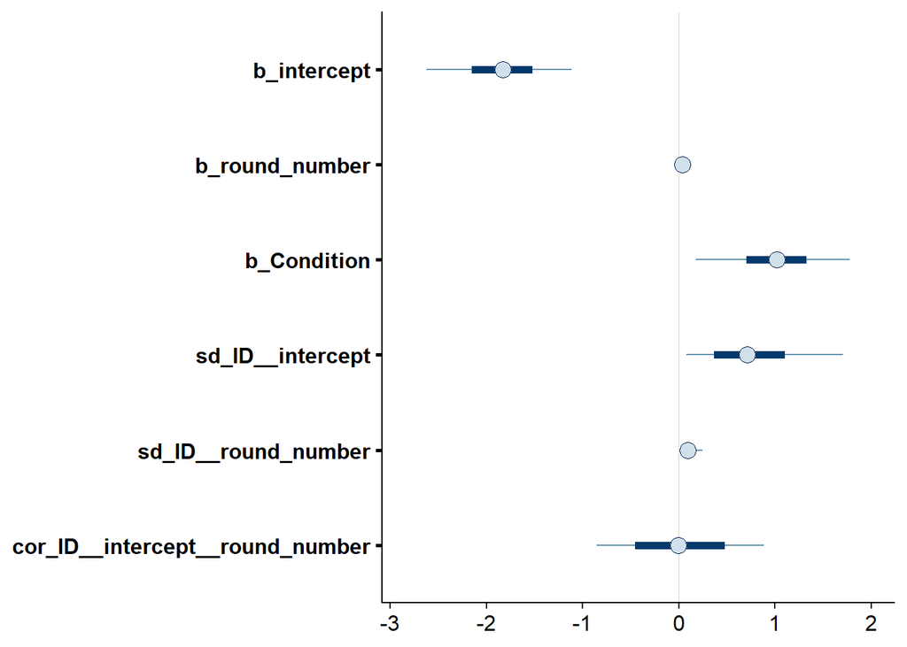

```r
stanplot(b4.5)
```

Let’s look at the trace plots to make sure Stan sampled efficiently.

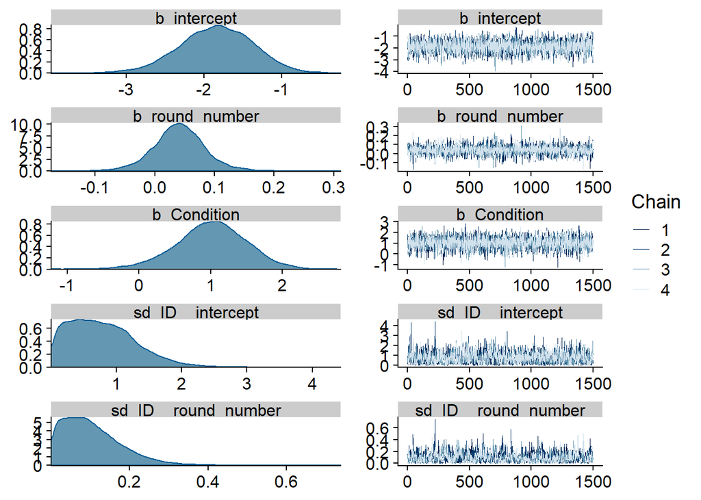

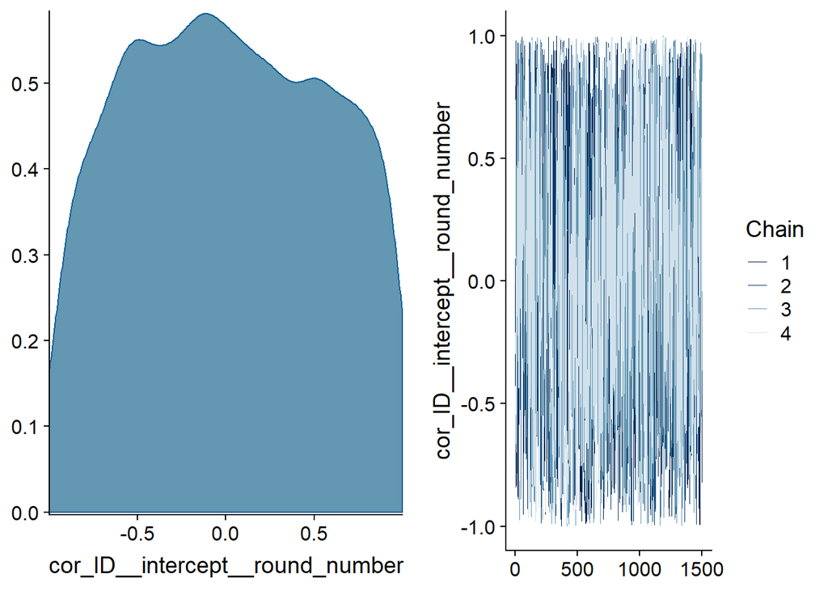

```r
plot(b4.5, ask = F)
```

There’s an effect of condition. Let’s convert to probability scale.

```r
post <- posterior_samples(b4.5)

visible_prob <- inv_logit_scaled(post$b_intercept)

visible_prob %>%
  median() %>%
  round(2)
```

```
## [1] 0.14
```

```r
hidden_prob  <- inv_logit_scaled(post$b_intercept + post$b_Condition)

hidden_prob %>%
  median() %>%
  round(2)
```

```
## [1] 0.31
```

What’s the difference in probabilities between conditions?

```r
difference <- hidden_prob - visible_prob
quantile(difference, c(0.025, 0.5, 0.975)) %>% round(2)
```

```
##  2.5%   50% 97.5%
##  0.00  0.16  0.34
```

Bayes Factor.

```r
(1 / hypothesis(b4.5, "inv_logit_scaled(intercept + Condition) - inv_logit_scaled(intercept) = 0", seed = 2113)$hypothesis$Evid.Ratio) %>% round(2)
```

```
## [1] 2.71
```

This Bayes Factor provides weak support for the hypothesis that the probabilities differ.

```r
bayes_R2(b4.5) %>% round(2)
```

```
##    Estimate Est.Error Q2.5 Q97.5
## R2     0.24      0.06 0.12  0.35
```

# 6. Binomial - Probability of not fulfilling a request when able

The data wrangling for this model is a little trickier.

1. First, we get a long-format data frame with (a) the player’s herd size that round, (b) how much the player received that round, and (c) how much the player requested that round.
2. Next, we flip the latter two variables to get (b’) how much the *player gave*, and (c’) how much the *player’s partner requested*. ‘Flipping’ is possible because partners sit next to the focal player in the data frame.
3. We drop rows with NAs, as no requesting happened this round.
4. We keep only rows in which the partner’s request could be fulfilled without dropping the player below the minimum survival threshold (i.e. the player was *able* to give).
5. We code whether the player fulfilled the request by giving what was asked or more (0) or did not fulfill the request (1).
6. We retain only Player 2s.

```r
(
  d.trim <-
    d %>%
    # 1. select herd size, received, and requested
    select(ID, IDinGroup, Condition, ends_with('.player.herd_size_after_shock'),
           ends_with('.player.received'),
           ends_with('.player.request_amount')) %>%
    # 2a. flip the variables to get what the player gave and what their partner requested
    mutate_at(vars(ends_with(".player.received"), ends_with(".player.request_amount")),
              function(x) x[1:nrow(d) + c(1,-1)]) %>%
    gather(key, value, -ID, -IDinGroup, -Condition) %>%
    extract(key, c("round_number", "variable"),
            "SurvivalGame.(.|..).player.(herd_size_after_shock|received|request_amount)") %>%
    mutate(value = as.numeric(value)) %>%
    spread(variable, value) %>%
    # 2b. rename the variables to match their new meaning
    rename(gave              = received,
           partner_requested = request_amount) %>%
    mutate(round_number      = as.integer(round_number)) %>%
    arrange(round_number, ID, IDinGroup, Condition) %>%
    # 3. drop NAs, as no requesting happened
    drop_na() %>%
    # 4. was the player able to give?
    filter(herd_size_after_shock - partner_requested >= 64) %>%
    # 5. code 0 = request fulfilled, 1 = request not fulfilled
    mutate(notFulfilled = ifelse(gave >= partner_requested, 0, 1) %>% as.integer()) %>%
    # 6. keep only Player 2s
    filter(IDinGroup == 2)
)
```

| ID | IDinGroup | Condition | round_number | herd_size_after_shock | gave | partner_requested | notFulfilled |
| --- | --- | --- | --- | --- | --- | --- | --- |
| 6 | 2 | 1 | 1 | 71 | 0 | 4 | 1 |
| 8 | 2 | 1 | 1 | 72 | 3 | 5 | 1 |
| 30 | 2 | 1 | 1 | 72 | 4 | 5 | 1 |
| 42 | 2 | 1 | 1 | 70 | 5 | 5 | 0 |
| 46 | 2 | 0 | 1 | 72 | 3 | 2 | 0 |
| 54 | 2 | 0 | 1 | 75 | 2 | 2 | 0 |
| 56 | 2 | 0 | 1 | 69 | 1 | 1 | 0 |
| 64 | 2 | 0 | 1 | 71 | 2 | 3 | 1 |
| 6 | 2 | 1 | 2 | 76 | 1 | 3 | 1 |
| 30 | 2 | 1 | 2 | 71 | 2 | 3 | 1 |

[output cut: 128 more lines]

This leaves us with 138 possible response decisions in which the player was able to give their partner what they asked for. Our outcome variable is whether they fulfilled that request or not.

We now fit the varying intercept and slope model, grouped by participant ID.

```r
b4.6 <-
  brm(data = d.trim, family = bernoulli,
      notFulfilled ~ 0 + intercept + round_number + Condition
      + (0 + intercept + round_number | ID),
      prior = c(prior(normal(0, 1), class = b),
                prior(student_t(3, 0, 10), class = sd),
                prior(lkj(1), class = cor)),
      control = list(adapt_delta = 0.99),
      sample_prior = TRUE,
      iter = 2500, warmup = 1000, chains = 4, cores = 4,
      seed = 2113)

save(b4.6, file = "models/exp4_brmsfit6.rda")
```

Here are the priors we used for model `b4.6`.

```r
prior_summary(b4.6)
```

| prior | class | coef | group | resp | dpar | nlpar | bound |
| --- | --- | --- | --- | --- | --- | --- | --- |
| normal(0, 1) | b |  |  |  |  |  |  |
|  | b | Condition |  |  |  |  |  |
|  | b | intercept |  |  |  |  |  |
|  | b | round_number |  |  |  |  |  |
| lkj_corr_cholesky(1) | L |  |  |  |  |  |  |
|  | L |  | ID |  |  |  |  |
| student_t(3, 0, 10) | sd |  |  |  |  |  |  |
|  | sd |  | ID |  |  |  |  |
|  | sd | intercept | ID |  |  |  |  |
|  | sd | round_number | ID |  |  |  |  |

Let’s see the results.

```r
print(b4.6)
```

```
##  Family: bernoulli
##   Links: mu = logit
## Formula: notFulfilled ~ 0 + intercept + round_number + Condition + (0 + intercept + round_number | ID)
##    Data: d.trim (Number of observations: 138)
## Samples: 4 chains, each with iter = 2500; warmup = 1000; thin = 1;
##          total post-warmup samples = 6000
##
## Group-Level Effects:
## ~ID (Number of levels: 31)
##                             Estimate Est.Error l-95% CI u-95% CI Eff.Sample Rhat
## sd(intercept)                   1.67      0.80     0.28     3.53       1277 1.00
## sd(round_number)                0.08      0.07     0.00     0.26        716 1.01
## cor(intercept,round_number)    -0.19      0.55    -0.96     0.91       2864 1.00
##
## Population-Level Effects:
##              Estimate Est.Error l-95% CI u-95% CI Eff.Sample Rhat
## intercept       -0.56      0.53    -1.63     0.50       3506 1.00
## round_number    -0.02      0.04    -0.11     0.06       3018 1.00
## Condition        0.85      0.63    -0.45     2.00       3124 1.00
##
## Samples were drawn using sampling(NUTS). For each parameter, Eff.Sample
## is a crude measure of effective sample size, and Rhat is the potential
## scale reduction factor on split chains (at convergence, Rhat = 1).
```

Plotting the parameters.

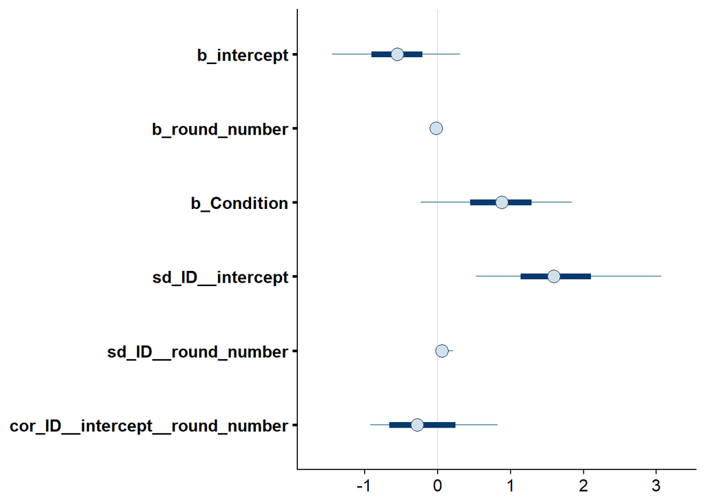

```r
stanplot(b4.6)
```

Let’s look at the trace plots to make sure Stan sampled efficiently.

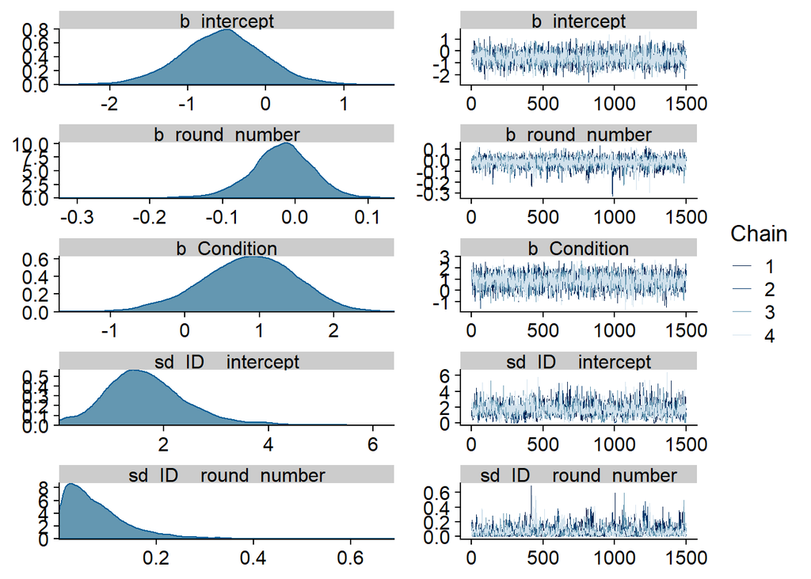

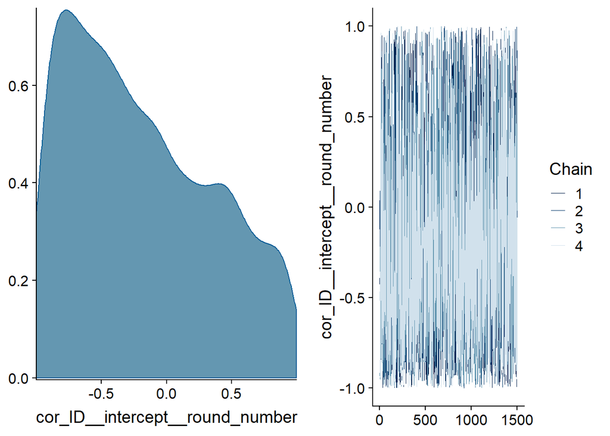

```r
plot(b4.6, ask = F)
```

Again, the RHat values, n_eff values, and trace plots look okay.

Let’s get estimates on the absolute probability scale.

```r
post <- posterior_samples(b4.6)

visible_prob <- inv_logit_scaled(post$b_intercept)

visible_prob %>%
  median() %>%
  round(2)
```

```
## [1] 0.37
```

```r
hidden_prob  <- inv_logit_scaled(post$b_intercept + post$b_Condition)

hidden_prob %>%
  median() %>%
  round(2)
```

```
## [1] 0.58
```

```r
difference <- hidden_prob - visible_prob
quantile(difference, c(0.025, 0.5, 0.975)) %>% round(2)
```

```
##  2.5%   50% 97.5%
## -0.10  0.20  0.45
```

Bayes Factor.

```r
(1 / hypothesis(b4.6, "inv_logit_scaled(intercept + Condition) - inv_logit_scaled(intercept) = 0", seed = 2113)$hypothesis$Evid.Ratio) %>% round(2)
```

```
## [1] 2.06
```

This Bayes Factor provides anecdotal support for the alternative (difference) over the null (no difference) hypothesis.

```r
bayes_R2(b4.6) %>% round(2)
```

```
##    Estimate Est.Error Q2.5 Q97.5
## R2     0.34      0.06 0.21  0.45
```

34% of the variance is explained by this model.

# 7. Plotting

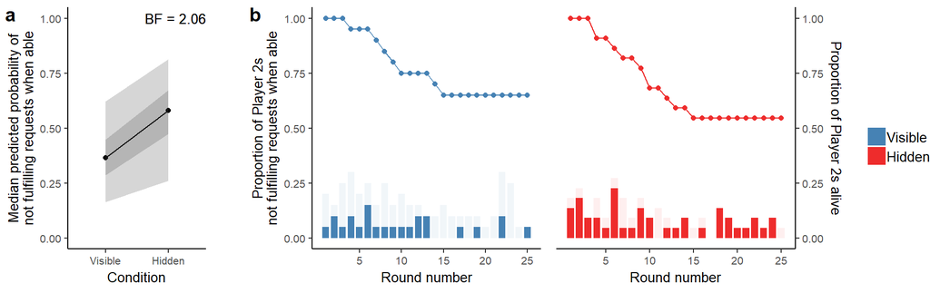